# 테일러 급수

테일러 급수(Taylor Series)는 주어진 함수 $ f(x) $를 특정한 점 $ a $ 근처에서 다항식으로 근사하는 방법입니다. 이 방법을 통해 함수가 무한히 미분 가능하다면, 함수 $ f(x) $는 무한한 항들로 이루어진 테일러 급수를 통해 완전히 표현될 수 있습니다. 그러나 실제 계산에서는 무한한 항을 모두 더할 수 없기 때문에, 유한 개의 항으로 함수 값을 근사하게 됩니다. 이 과정에서 발생하는 오차를 절단오차(Truncation Error)라고 합니다.

### 테일러 급수의 전개

함수 $ f(x) $가 주어진 점 $ a $에서 무한히 미분 가능하다면, $ f(x) $는 그 점에서의 테일러 급수로 전개될 수 있습니다:

$$ f(x) = \sum_{n=0}^{\infty} \frac{f^{(n)}(a)}{n!} (x - a)^n $$

여기서:

- $ f^{(n)}(a) $는 $ f(x) $의 $ a $에서의 n차 도함수입니다.
- $ n! $는 n의 팩토리얼입니다.
- $ (x - a)^n $은 $ x $와 기준점 $ a $ 사이의 차를 나타냅니다.

이 식은 무한한 항을 포함하는데, 실제로는 계산에 있어 유한한 항만을 사용합니다. 이를 유한 차수의 테일러 급수라고 하며, 이때 발생하는 오차가 바로 절단오차입니다.

### 절단오차(Truncation Error)

테일러 급수를 계산할 때, 우리는 일반적으로 무한한 항을 모두 계산할 수 없으므로 유한한 항까지만 사용하여 근사합니다. 이때 무시된 항들로 인해 발생하는 오차를 절단오차라고 합니다.

만약 테일러 급수를 $ n $차 항까지 계산하면, 실제 함수와 $ n $차 테일러 급수로 근사한 값 사이의 차이를 절단오차라고 부릅니다.

#### 절단오차의 표현

만약 $ f(x) $를 $ n $차 테일러 다항식 $ P_n(x) $로 근사한다면, $ f(x) $와 $ P_n(x) $ 사이의 차이는 다음과 같이 표현됩니다:

$$ R_n(x) = f(x) - P_n(x) $$

이때 절단오차 $ R_n(x) $는 보통 테일러의 나머지 항으로 불리며, 다음과 같은 형태를 가집니다:

$$ R_n(x) = \frac{f^{(n+1)}(c)}{(n+1)!}(x - a)^{n+1} $$

여기서:

- $ c $는 $ a $와 $ x $ 사이에 있는 어떤 값입니다 (일반적으로는 알려져 있지 않음).
- $ f^{(n+1)}(c) $는 $ c $에서의 $ f(x) $의 $ (n+1) $차 도함수입니다.

이 식은 나머지 항(오차 항)이 함수의 $ (n+1) $차 도함수에 의존하며, $ (x - a) $의 $ (n+1) $차 항으로 감소함을 보여줍니다.

#### 절단오차의 의미

- 오차의 크기는 주어진 $ x $와 $ a $ 사이의 차이에 따라 달라집니다.
- 높은 차수의 항을 더 많이 계산할수록, 절단오차는 작아집니다.
- 함수가 더 높은 차수에서 잘 수렴한다면, 적은 항으로도 근사 정확도를 높일 수 있습니다.

### 예시

#### $ e^x $ 함수의 테일러 급수

지수 함수 $ f(x) = e^x $의 테일러 급수는 다음과 같습니다:

$$ e^x = \sum_{n=0}^{\infty} \frac{x^n}{n!} = 1 + x + \frac{x^2}{2!} + \frac{x^3}{3!} + \dots $$

만약 $ e^x $를 $ n = 2 $차까지 계산한다고 하면, 이는 다음과 같은 다항식으로 근사됩니다:

$$ e^x \approx 1 + x + \frac{x^2}{2!} $$

이때, 절단오차는 다음과 같은 형태를 가집니다:

$$ R_2(x) = \frac{e^c}{3!} x^3 $$

여기서 $ c $는 $ 0 \leq c \leq x $인 값입니다. 즉, 절단오차는 무시한 3차 이상의 항에서 발생하며, 그 크기는 $ x^3 $에 비례하게 됩니다.

#### $ \sin(x) $ 함수의 테일러 급수

사인 함수 $ \sin(x) $는 다음과 같은 형태로 전개됩니다:

$$ \sin(x) = x - \frac{x^3}{3!} + \frac{x^5}{5!} - \dots $$

만약 $ \sin(x) $를 $ n = 1 $차까지만 계산한다고 가정하면:

$$ \sin(x) \approx x $$

이때 절단오차는 다음과 같습니다:

$$ R_1(x) = \frac{\sin(c)}{3!} x^3 $$

따라서, 3차 이상의 항을 무시했기 때문에 절단오차는 $ x^3 $에 비례하는 크기로 발생합니다.

### 테일러 급수의 활용

1. 함수의 근사 계산: 테일러 급수를 사용하여 복잡한 함수 값을 근사적으로 계산할 수 있습니다.
2. 수치 해석: 수치 해석에서 비선형 방정식의 해를 구하거나, 미분 방정식을 풀 때 테일러 급수를 많이 사용합니다.
3. 과학 및 공학 문제: 물리학이나 공학에서 주어진 함수의 값이 특정 값 근처에서 어떻게 변화하는지 분석할 때 사용됩니다.

### 요약

- 테일러 급수는 함수가 특정 점 근처에서 어떻게 변하는지를 다항식으로 나타내는 방법입니다.
- 실제 계산에서는 유한한 차수의 테일러 다항식을 사용하므로 절단오차가 발생합니다.
- 절단오차는 함수의 더 높은 차수의 도함수에 의존하며, 무시한 항들의 영향을 나타냅니다.
- 테일러 급수는 함수의 근사 계산, 수치 해석, 공학적 문제 해결 등에서 중요한 역할을 합니다.

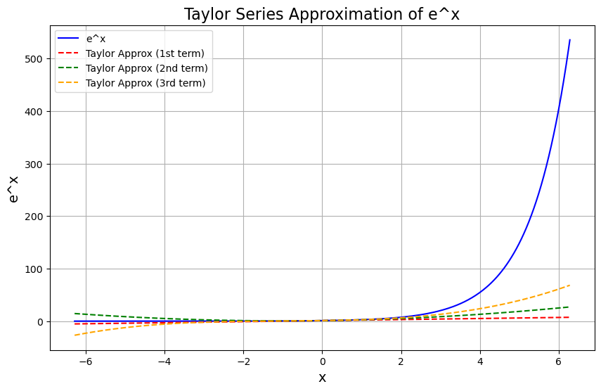

```python
import math
import matplotlib.pyplot as plt
import numpy as np

x_values = np.linspace(-2 * np.pi, 2 * np.pi, 400)

# 테일러 급수를 이용해 e^x를 근사하는 함수
def taylor_exp(x, n):
    approx = 0
    for i in range(n + 1):
        term = (x**i) / math.factorial(i)  # (x^i) / i!
        approx += term
    return approx

# 실제 e^x와 테일러 급수로 근사한 값을 비교
exp_values = np.exp(x_values)

# 테일러 급수로 근사한 값 (1차, 2차, 3차까지)
taylor_exp_1_values = [taylor_exp(x, 1) for x in x_values]  # 1차까지
taylor_exp_2_values = [taylor_exp(x, 2) for x in x_values]  # 2차까지
taylor_exp_3_values = [taylor_exp(x, 3) for x in x_values]  # 3차까지

# 그래프 그리기
plt.figure(figsize=(10, 6))
plt.plot(x_values, exp_values, label='e^x', color='blue')
plt.plot(x_values, taylor_exp_1_values, label='Taylor Approx (1st term)', linestyle='--', color='red')
plt.plot(x_values, taylor_exp_2_values, label='Taylor Approx (2nd term)', linestyle='--', color='green')
plt.plot(x_values, taylor_exp_3_values, label='Taylor Approx (3rd term)', linestyle='--', color='orange')

# 그래프 레이블
plt.title('Taylor Series Approximation of e^x', fontsize=16)
plt.xlabel('x', fontsize=14)
plt.ylabel('e^x', fontsize=14)
plt.legend()
plt.grid(True)

# 그래프 표시
plt.show()
```

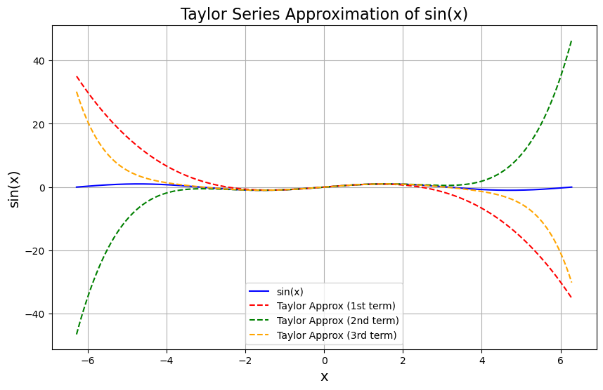

```python
import math
import matplotlib.pyplot as plt
import numpy as np

# 테일러 급수를 이용해 sin(x)를 근사하는 함수
def taylor_sin(x, n):
    approx = 0
    for i in range(n + 1):
        coeff = (-1)**i  # 계수 (-1)^i
        term = (x**(2 * i + 1)) / math.factorial(2 * i + 1)  # (x^(2i+1)) / (2i+1)!
        approx += coeff * term
    return approx

# 실제 sin(x)와 테일러 급수로 근사한 값을 비교
x_values = np.linspace(-2 * np.pi, 2 * np.pi, 400)
sin_values = np.sin(x_values)

# 테일러 급수로 근사한 값 (3차, 5차, 7차까지)
taylor_3_values = [taylor_sin(x, 1) for x in x_values]  # 3차 (1차까지)
taylor_5_values = [taylor_sin(x, 2) for x in x_values]  # 5차 (2차까지)
taylor_7_values = [taylor_sin(x, 3) for x in x_values]  # 7차 (3차까지)

# 그래프 그리기
plt.figure(figsize=(10, 6))
plt.plot(x_values, sin_values, label='sin(x)', color='blue')
plt.plot(x_values, taylor_3_values, label='Taylor Approx (1st term)', linestyle='--', color='red')
plt.plot(x_values, taylor_5_values, label='Taylor Approx (2nd term)', linestyle='--', color='green')
plt.plot(x_values, taylor_7_values, label='Taylor Approx (3rd term)', linestyle='--', color='orange')

# 그래프 레이블
plt.title('Taylor Series Approximation of sin(x)', fontsize=16)
plt.xlabel('x', fontsize=14)
plt.ylabel('sin(x)', fontsize=14)
plt.legend()
plt.grid(True)

# 그래프 표시
plt.show()
```

## 수치해석의 오차

1. Truncation error: 절단 오차, 무한급수인 테일러 급수를 유한차항까지만 포함해서 생긴 오차.
2. Round off error: 컴퓨터의 부동소수점 연산에 의해 발생하는 오차.

수치해석을 할 때엔 반드시 수치적 방법에 따른 오차도 제시하여야 한다.

**오차의 표기법**

- $R_n(h)$
- $\sigma(h^n)$

수치해석에서의 오차는 실제 값과 계산된 근사값 사이의 차이를 나타내며, 일반적으로 두 가지 오차로 나뉩니다: 절대오차와 상대오차. 이 두 오차는 수치해석 문제에서 근사값의 정확도를 평가하는 데 사용됩니다.

### 1. 절대오차 (Absolute Error)

절대오차는 실제 값과 근사값 간의 차이의 절대값을 나타냅니다.

$$ \text{절대오차} = |\text{실제 값} - \text{근사 값}| $$

- 실제 값: 우리가 이상적으로 계산해야 하는 값 또는 참 값.
- 근사 값: 수치적으로 계산된 값.

#### 예시:

만약 실제 값이 10이고, 계산된 근사 값이 9.8이라면:

$$ \text{절대오차} = |10 - 9.8| = 0.2 $$

### 2. 상대오차 (Relative Error)

상대오차는 절대오차를 실제 값으로 나누어, 오차의 크기가 실제 값에 비해 얼마나 큰지를 나타냅니다. 상대오차는 특히 값의 크기에 따라 절대오차가 큰 의미를 갖지 않을 때 유용합니다.

$$ \text{상대오차} = \frac{|\text{실제 값} - \text{근사 값}|}{|\text{실제 값}|} $$

- 상대오차는 실제 값에 대한 오차의 비율을 나타내며, 비교적 작은 값이거나 큰 값에서 더 의미 있는 결과를 제공합니다.

#### 예시:

실제 값이 1000이고 계산된 근사 값이 999라면:

$$ \text{상대오차} = \frac{|1000 - 999|}{|1000|} = \frac{1}{1000} = 0.001 $$

### 3. 백분율 상대오차 (Percentage Relative Error)

상대오차를 퍼센트로 나타낸 형태로, 상대오차에 100을 곱한 값입니다. 수치 해석 문제에서 퍼센트 오차는 오차의 크기를 직관적으로 파악하는 데 유용합니다.

$$ \text{백분율 상대오차} = \left( \frac{|\text{실제 값} - \text{근사 값}|}{|\text{실제 값}|} \right) \times 100 $$

#### 예시:

위 예시에서 상대오차가 0.001이었다면, 백분율 상대오차는:

$$ \text{백분율 상대오차} = 0.001 \times 100 = 0.1\% $$

### 4. 절단오차 (Truncation Error)

절단오차는 수치해석에서 무한 급수를 유한한 항까지만 계산할 때 발생하는 오차입니다. 이는 테일러 급수와 같은 무한 급수의 특정 항 이후를 무시할 때 발생하는 오차입니다. 일반적으로 절단오차는 다음과 같이 표현됩니다:

$$ R_n(x) = \frac{f^{(n+1)}(c)}{(n+1)!}(x - a)^{n+1} $$

여기서 $ c $는 $ a $와 $ x $ 사이의 값이며, 이 식은 나머지 항을 나타냅니다. 절단오차는 무시된 항들의 합으로 발생합니다.

### 5. 반올림오차 (Rounding Error)

반올림오차는 유한한 자릿수로 숫자를 표현할 때 발생하는 오차입니다. 컴퓨터는 실수를 무한히 정확하게 표현하지 못하기 때문에, 소수점 아래 자릿수를 제한할 경우 반올림오차가 발생할 수 있습니다.

#### 반올림오차의 예:

만약 실제 값이 $ 3.1415926535 \dots $이고 이를 $ 3.14 $로 표현한다면, 반올림오차는:

$$ \text{반올림오차} = |3.1415926535 - 3.14| = 0.0015926535 $$

### 요약

수치해석에서 오차를 계산하는 방법은 다음과 같습니다:

- 절대오차: $ \text{절대오차} = |\text{실제 값} - \text{근사 값}| $
- 상대오차: $ \text{상대오차} = \frac{|\text{실제 값} - \text{근사 값}|}{|\text{실제 값}|} $
- 백분율 상대오차: $ \text{백분율 상대오차} = \left( \frac{|\text{실제 값} - \text{근사 값}|}{|\text{실제 값}|} \right) \times 100 $
- 절단오차: 무한 급수에서 유한한 항까지만 계산한 후 발생하는 오차.
- 반올림오차: 유한 자릿수의 표현으로 인해 발생하는 오차.

이러한 오차 공식들을 통해 수치해석에서 근사한 값이 얼마나 정확한지를 평가할 수 있습니다.

절단오차를 보다 구체적으로 계산할 때, 특히 테일러 급수의 나머지 항을 계산할 때는 함수의 고차 도함수의 최대값을 사용하여 오차를 평가하는 경우가 있습니다. 예를 들어, 테일러 급수의 절단오차는 해당 함수의 고차 도함수의 크기에 크게 의존하므로, 절단오차를 보다 직관적으로 표현하기 위해 도함수의 최대값을 사용합니다. 이를 오차 상한(Bound on Error)이라고 부르기도 합니다.

### 절단오차 계산의 상한: $ |f^{(n+1)}(c)|_{\text{max}} $

테일러 급수에서 절단오차는 일반적으로 다음과 같은 형태로 주어집니다:

$$ R_n(x) = \frac{f^{(n+1)}(c)}{(n+1)!}(x - a)^{n+1} $$

여기서:

- $ f^{(n+1)}(c) $는 함수 $ f(x) $의 $ (n+1) $차 도함수이며, $ c $는 $ a $와 $ x $ 사이의 어떤 값입니다.
- 절단오차는 $ f(x) $의 도함수의 크기에 따라 결정되므로, 함수의 고차 도함수 $ f^{(n+1)}(c) $의 값이 크면 절단오차도 커집니다.

절단오차를 계산할 때는 보통 $ c $의 값을 정확히 알 수 없기 때문에, 구간 내에서 $ f^{(n+1)}(x) $의 최댓값을 사용해 오차를 상한으로 평가합니다. 즉, $ c $ 대신 구간 내에서 도함수의 최대값 $ |f^{(n+1)}(x)|_{\text{max}} $를 사용하여 절단오차를 다음과 같이 표현할 수 있습니다:

$$ |R_n(x)| \leq \frac{|f^{(n+1)}(x)|_{\text{max}}}{(n+1)!} |x - a|^{n+1} $$

이 식은 절단오차의 최대 상한을 나타냅니다.

### 절단오차 상한 계산의 예시

#### 1. $ e^x $ 함수의 절단오차

지수 함수 $ e^x $의 테일러 급수는 다음과 같습니다:

$$ e^x = 1 + x + \frac{x^2}{2!} + \frac{x^3}{3!} + \dots $$

만약 $ n = 2 $차 항까지만 계산한다고 하면:

$$ e^x \approx 1 + x + \frac{x^2}{2!} $$

이때 절단오차 $ R_2(x) $는 다음과 같이 계산할 수 있습니다:

$$ R_2(x) = \frac{e^c}{3!} x^3 $$

여기서 $ c $는 $ 0 \leq c \leq x $입니다. 그런데 $ e^c $는 $ c $ 값에 상관없이 항상 양수이고 $ e^x $의 모든 도함수는 $ e^x $ 그 자체이므로, 도함수의 최댓값은 단순히 $ e^x $의 최댓값이 됩니다. 따라서 절단오차의 상한은 다음과 같이 표현할 수 있습니다:

$$ |R_2(x)| \leq \frac{e^{x_{\text{max}}}}{3!} |x|^3 $$

여기서 $ x_{\text{max}} $는 $ x $의 최대값입니다.

#### 2. $ \sin(x) $ 함수의 절단오차

사인 함수 $ \sin(x) $의 테일러 급수는 다음과 같습니다:

$$ \sin(x) = x - \frac{x^3}{3!} + \frac{x^5}{5!} - \dots $$

만약 $ n = 1 $차 항까지만 계산한다면:

$$ \sin(x) \approx x $$

이때 절단오차 $ R_1(x) $는 다음과 같습니다:

$$ R_1(x) = \frac{\sin(c)}{3!} x^3 $$

사인 함수의 모든 도함수는 절댓값이 $ 1 $을 넘지 않으므로, 절단오차 상한은 다음과 같이 나타낼 수 있습니다:

$$ |R_1(x)| \leq \frac{1}{3!} |x|^3 $$

즉, $ \sin(x) $ 함수의 경우 절단오차는 $ \frac{|x|^3}{6} $로 제한됩니다.

### 요약

- 절단오차 상한은 테일러 급수에서 무시된 항에 의해 발생하는 오차를 평가하기 위해 사용됩니다.
- 절단오차의 상한은 함수의 고차 도함수의 최댓값 $ |f^{(n+1)}(x)|_{\text{max}} $에 의존합니다.
- 상한 공식: $$ |R_n(x)| \leq \frac{|f^{(n+1)}(x)|_{\text{max}}}{(n+1)!} |x - a|^{n+1} $$
- 이 공식은 테일러 급수 전개에서 남은 항들의 크기를 평가하여 절단오차의 최대값을 계산할 수 있는 도구입니다.

절단오차 상한을 계산함으로써, 함수의 근사가 얼마나 정확한지에 대한 최악의 시나리오를 알 수 있고, 이를 통해 필요한 근사 차수를 결정할 수 있습니다.

```python
import math

# 테일러 급수로 절단오차를 계산하는 함수
def truncation_error_exp(x, n):
    # 절단오차 상한 계산 for e^x
    error = abs((math.exp(x)) / math.factorial(n + 1)) * abs(x ** (n + 1))
    return error

def truncation_error_sin(x, n):
    # 절단오차 상한 계산 for sin(x), sin의 도함수는 최대값이 1
    error = abs(1 / math.factorial(n + 1)) * abs(x ** (n + 1))
    return error

# 입력 값
x_exp = 1  # e^x 계산에서 x값
n_exp = 2  # e^x의 2차 테일러 급수
x_sin = 1  # sin(x) 계산에서 x값
n_sin = 1  # sin(x)의 1차 테일러 급수

# e^x 절단오차 계산
exp_error = truncation_error_exp(x_exp, n_exp)

# sin(x) 절단오차 계산
sin_error = truncation_error_sin(x_sin, n_sin)

# 결과 출력
print(f"e^{x_exp} 절단오차 (n = {n_exp}차): {exp_error}")
print(f"sin({x_sin}) 절단오차 (n = {n_sin}차): {sin_error}")
```

```
e^1 절단오차 (n = 2차): 0.45304697140984085
sin(1) 절단오차 (n = 1차): 0.5
```

함수 $ f(x) = \ln(1 - x) $의 테일러 급수를 $ x = 0 $에서 전개하고, 절단오차를 분석하는 과정을 설명하겠습니다.

### 1. 테일러 급수 전개

테일러 급수는 함수 $ f(x) $가 특정 점 $ a = 0 $에서 무한히 미분 가능할 때, 다음과 같이 전개됩니다:

$$ f(x) = f(0) + f'(0)x + \frac{f''(0)}{2!}x^2 + \frac{f^{(3)}(0)}{3!}x^3 + \dots $$

#### 함수 $ f(x) = \ln(1 - x) $의 도함수 계산

- $ f(x) = \ln(1 - x) $
- $ f'(x) = \frac{-1}{1 - x} $
- $ f''(x) = \frac{-1}{(1 - x)^2} $
- $ f^{(3)}(x) = \frac{-2}{(1 - x)^3} $
- $ f^{(4)}(x) = \frac{-6}{(1 - x)^4} $

#### $ x = 0 $에서의 도함수 값

- $ f(0) = \ln(1 - 0) = 0 $
- $ f'(0) = -1 $
- $ f''(0) = -1 $
- $ f^{(3)}(0) = -2 $
- $ f^{(4)}(0) = -6 $

따라서, $ x = 0 $에서의 테일러 급수는 다음과 같습니다:

$$ f(x) = 0 - x - \frac{x^2}{2} - \frac{2x^3}{6} - \frac{6x^4}{24} + \dots $$ 이를 정리하면:

$$ \ln(1 - x) = -x - \frac{x^2}{2} - \frac{x^3}{3} - \frac{x^4}{4} + \dots $$

### 2. 테일러 급수의 일반항

일반적으로, $ \ln(1 - x) $의 테일러 급수는 다음과 같이 표현할 수 있습니다:

$$ \ln(1 - x) = - \sum_{n=1}^{\infty} \frac{x^n}{n} $$

### 3. 절단오차 분석

절단오차는 테일러 급수의 나머지 항에 의해 발생하는 오차로, $ n $-차 테일러 다항식을 사용하여 계산할 때 남은 부분입니다. 절단오차는 다음과 같이 표현됩니다:

$$ R_n(x) = \frac{f^{(n+1)}(c)}{(n+1)!}(x - a)^{n+1} $$

여기서 $ c $는 $ a $와 $ x $ 사이의 값입니다. 테일러 급수를 $ n $차 항까지 사용한 경우, 나머지 항을 무시한 절단오차는 그 이후 항에 의해 결정됩니다.

### 4. 오차 계산 및 출력 (파이썬 코드)

이제 테일러 급수를 사용하여 $ f(x) = \ln(1 - x) $를 근사하고 절단오차를 계산하는 파이썬 코드를 작성하겠습니다. $ x = 0.5 $일 때, 3차 항까지만 계산하고 절단오차를 분석하겠습니다.

```python
# f(x) = ln(1 - x)의 테일러 급수 전개 및 절단오차 계산

import math

# 테일러 급수로 ln(1 - x) 근사
def taylor_ln_1_minus_x(x, n):
    approx = 0
    for i in range(1, n + 1):
        approx += (-x**i)/i
    return approx

# 절단오차 계산
def truncation_error_ln_1_minus_x(x, n):
    # 절단 오차는 (n+1)차 항의 크기
    return abs(x**(n+1) / math.factorial(n+1)) * abs(-math.factorial(n-1)/(1-x)**n)

# 설정값
x_value = 0.5  # x = 0.5에서 근사
n_order = 3   # 근사 차수

# ln(1 - x)의 n_order차 테일러 급수 근사 및 절단오차 계산
taylor_approx = taylor_ln_1_minus_x(x_value, n_order)
trunc_error = truncation_error_ln_1_minus_x(x_value, n_order)

# 실제 값 계산
actual_value = math.log(1 - x_value)

# 결과 출력
print(f"ln(1 - {x_value})의 실제 값: {actual_value}")
print(f"{n_order}차 테일러 급수로 근사한 값: {taylor_approx}")
print(f"절단오차: {trunc_error}")
```

```
ln(1 - 0.5)의 실제 값: -0.6931471805599453
3차 테일러 급수로 근사한 값: -0.6666666666666666
절단오차: 0.041666666666666664
```

결과는 다음과 같습니다:

- $ \ln(1 - 0.5) $의 실제 값: -0.6931
- 3차 테일러 급수로 근사한 값: -0.6667
- 절단오차: 0.04167

## 테일러 급수의 수렴반경(Radius of Convergence)

테일러 급수의 수렴 반경(Radius of Convergence) 은 함수의 테일러 급수가 수렴하는 구간을 나타냅니다. 주어진 함수의 테일러 급수는 특정 구간 내에서만 수렴할 수 있으며, 이 구간의 반경을 수렴 반경이라 부릅니다.

### 1. 테일러 급수의 일반형

함수 $ f(x) $가 점 $ a $에서 테일러 급수로 전개될 수 있다고 할 때, 테일러 급수의 일반적인 형태는 다음과 같습니다:

$$ f(x) = \sum_{n=0}^{\infty} \frac{f^{(n)}(a)}{n!} (x - a)^n $$

여기서:

- $ f^{(n)}(a) $는 $ f(x) $의 $ a $에서의 $ n $-차 도함수입니다.
- $ a $는 급수의 전개점 (중심점)입니다.
- $ (x - a) $는 급수가 전개되는 변수입니다.

이 테일러 급수는 수렴 반경 $ R $에 따라 특정 범위 내에서만 수렴할 수 있습니다.

### 2. 수렴 반경의 정의

테일러 급수의 수렴 반경 $ R $은 급수가 수렴하는 거리, 즉 중심점 $ a $로부터 수렴하는 $ x $ 값의 최대 거리를 나타냅니다. 수렴 반경 $ R $은 다음 두 가지 방법으로 구할 수 있습니다:

#### (1) 비율 판정법 (Ratio Test)

비율 판정법을 사용하여 수렴 반경을 구할 수 있습니다. 주어진 테일러 급수의 계수 $ c_n = \frac{f^{(n)}(a)}{n!} $에 대해, 수렴 반경 $ R $은 다음과 같이 구할 수 있습니다:

$$ R = \lim_{n \to \infty} \left| \frac{c_n}{c_{n+1}} \right| $$

#### (2) 근 판정법 (Root Test)

계수 $ c_n $의 $ n $-제곱근의 상극한을 사용하여 수렴 반경을 구할 수도 있습니다:

$$ R = \frac{1}{\limsup_{n \to \infty} \sqrt[n]{|c_n|}} $$

여기서 $ R $은 테일러 급수의 수렴 반경이며, 이 반경 내에서는 급수가 수렴하고 그 바깥에서는 발산합니다.

### 3. 수렴 반경의 의미

- 수렴 구간: $ |x - a| < R $에서 급수는 수렴합니다.
- 발산 구간: $ |x - a| > R $에서는 급수는 발산합니다.
- $ |x - a| = R $인 경우는 별도로 분석해야 하며, 그 지점에서 급수가 수렴하거나 발산할 수 있습니다.

### 4. 수렴 반경 계산 예시

#### (1) $ \frac{1}{1 - x} $의 테일러 급수

함수 $ f(x) = \frac{1}{1 - x} $의 테일러 급수는 $ x = 0 $에서 다음과 같이 전개됩니다:

$$ \frac{1}{1 - x} = \sum_{n=0}^{\infty} x^n $$

이 급수의 계수는 $ c_n = 1 $이므로, 비율 판정법을 사용하면:

$$ R = \lim_{n \to \infty} \left| \frac{1}{1} \right| = 1 $$

따라서 이 테일러 급수의 수렴 반경은 $ R = 1 $입니다. 이는 $ |x| < 1 $에서 급수가 수렴하고, $ |x| \geq 1 $에서 급수가 발산함을 의미합니다.

#### (2) $ e^x $의 테일러 급수

함수 $ f(x) = e^x $의 테일러 급수는 다음과 같습니다:

$$ e^x = \sum_{n=0}^{\infty} \frac{x^n}{n!} $$

이 급수의 계수는 $ c_n = \frac{1}{n!} $입니다. 비율 판정법을 사용하여 수렴 반경을 계산하면:

$$ R = \lim_{n \to \infty} \left| \frac{\frac{1}{n!}}{\frac{1}{(n+1)!}} \right| = \lim_{n \to \infty} (n + 1) = \infty $$

따라서 $ e^x $의 테일러 급수는 모든 $ x $에서 수렴하며, 수렴 반경은 $ R = \infty $입니다.

### 5. 수렴 반경 요약

- 수렴 반경은 테일러 급수나 멱급수가 특정 구간에서 수렴하는지 여부를 결정하는 중요한 척도입니다.
- 수렴 반경 $ R $은 비율 판정법이나 근 판정법을 통해 계산할 수 있으며, 그 값에 따라 급수가 수렴하는 구간이 결정됩니다.
- 급수는 $ |x - a| < R $에서 수렴하고, $ |x - a| > R $에서 발산합니다. $ |x - a| = R $에서는 수렴 여부를 별도로 분석해야 합니다.

테일러 급수에서 수렴 반경을 통해 함수의 급수 표현이 어느 범위에서 유효한지 알 수 있습니다.